# Project 3

Marissa He

## Part 1: Regression analysis of Gapminder data

```python
import pandas as pd
import matplotlib.pyplot as plt
import numpy as np
from ggplot import *
from scipy import stats
from sklearn import linear_model
from sklearn import datasets
from sklearn import tree
from sklearn.metrics import r2_score
from sklearn.model_selection import KFold
from sklearn.model_selection import cross_val_score
from sklearn.preprocessing import PolynomialFeatures
from sklearn.svm import LinearSVC
from sklearn.pipeline import make_pipeline
from sklearn.preprocessing import StandardScaler
from sklearn.datasets import make_classification

data = pd.read_csv("gap.tsv", sep='\t')
data.head()
```

|  | country | continent | year | lifeExp | pop | gdpPercap |
| --- | --- | --- | --- | --- | --- | --- |
| 0 | Afghanistan | Asia | 1952 | 28.801 | 8425333 | 779.445314 |
| 1 | Afghanistan | Asia | 1957 | 30.332 | 9240934 | 820.853030 |
| 2 | Afghanistan | Asia | 1962 | 31.997 | 10267083 | 853.100710 |
| 3 | Afghanistan | Asia | 1967 | 34.020 | 11537966 | 836.197138 |
| 4 | Afghanistan | Asia | 1972 | 36.088 | 13079460 | 739.981106 |

### Exercise 1

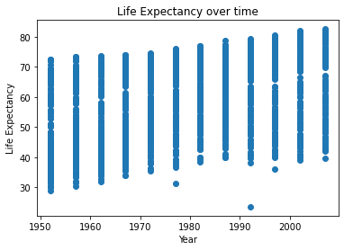

```python
plt.figure()
plt.xlabel('Year')
plt.ylabel('Life Expectancy')
plt.scatter(data.year, data.lifeExp)
plt.title('Life Expectancy over time')
```

### Question 1

Is there a general trend (e.g., increasing or decreasing) for life expectancy across time? Is this trend linear? (answering this qualitatively from the plot, you will do a statistical analysis of this question shortly)

There is an increasing linear trend for life expectancy across time, as the range of life expectancies increase by around the same amount each year.

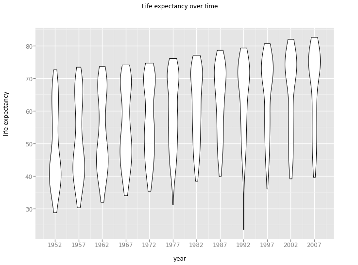

```python
ggplot(aes(x='year', y='lifeExp'), data=data) +\
    geom_violin() +\
    labs(title="Life expectancy over time",
         x = "year",
         y = "life expectancy")
```

### Question 2

How would you describe the distribution of life expectancy across countries for individual years? Is it skewed, or not? Unimodal or not? Symmetric around it’s center?

In earlier years, from 1952-1962, the life expectancy was unimodal and skewed towards the higher side, with mode around 40. For 1967-1972, the distribution was bimodal, with modes around 50 and 70, and skewed lower. From 1977-2007, it was unimodal again, but this time lower skewed.

### Question 3

Suppose I fit a linear regression model of life expectancy vs. year (treating it as a continuous variable), and test for a relationship between year and life expectancy, will you reject the null hypothesis of no relationship? (do this without fitting the model yet. I am testing your intuition.)

I will reject the null hypothesis of no relationship, because from the scatter plot it looks to be linear.

### Question 4

What would a violin plot of residuals from the linear model in Question 3 vs. year look like? (Again, don’t do the analysis yet, answer this intuitively)

I think it would have more positive residuals in the earlier years (before 1977), then more negative residuals in the later years (after 1982).

### Question 5

According to the assumptions of the linear regression model, what should that violin plot look like? That is, consider the assumptions the linear regression model you used assumes (e.g., about noise, about input distributions, etc); do you think everything is okay?

In a well fitting linear regression, the violin plot should be symmetric and unimodal around 0, indicating that the residuals are normally distributed with a mean/center of 0 residue.

### Exercise 2

```
life expectancy = 0.32590382763715164 * year + ( -585.6521874415445 )
```

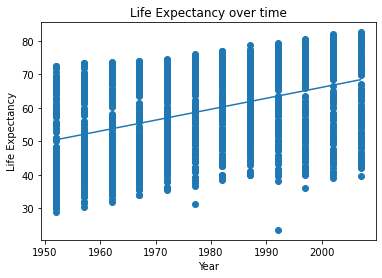

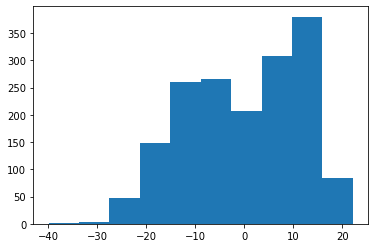

```python
reg = linear_model.LinearRegression()
year = np.array([[y] for y in data.year])
reg.fit(year, data.lifeExp)
print("life expectancy =", reg.coef_[0], "* year + (", reg.intercept_, ")")
plt.xlabel('Year')
plt.ylabel('Life Expectancy')
plt.scatter(data.year, data.lifeExp)
plt.plot(data.year, reg.coef_[0]*data.year+reg.intercept_)
plt.title('Life Expectancy over time')

plt.figure()
data['residual'] = data['lifeExp']-(reg.coef_[0]*data['year']+reg.intercept_)
plt.hist(data['residual'])
```

### Question 6

On average, by how much does life expectancy increase every year around the world?

Life expectancy increases 0.326 years on average, or around 119 days.

### Question 7

Do you reject the null hypothesis of no relationship between year and life expectancy? Why?

I do reject the null hypothesis, because the linear regression found that there is a positive linear relationship between year and life expectancy. The scatter plot points are spread evenly around the linear regression, and the histogram of residuals seems to be left skewed normally distributed, so the linear regression fits.

### Exercise 3

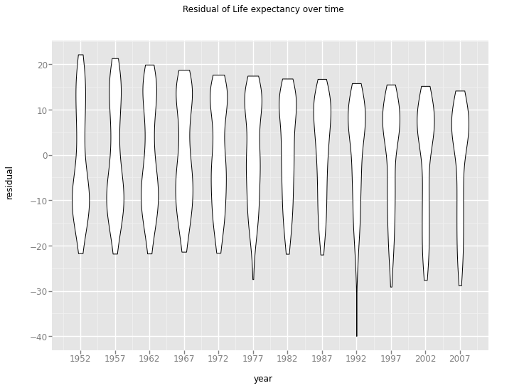

```python
data['residual'] = data['lifeExp']-(reg.coef_[0]*data['year']+reg.intercept_)
ggplot(aes(x='year', y='residual'), data=data) +\
    geom_violin() +\
    labs(title="Residual of Life expectancy over time",
         x = "year",
         y = "residual")
```

### Question 8

Does the plot of Exercise 3 match your expectations (as you answered Question 4)?

### Exercise 4

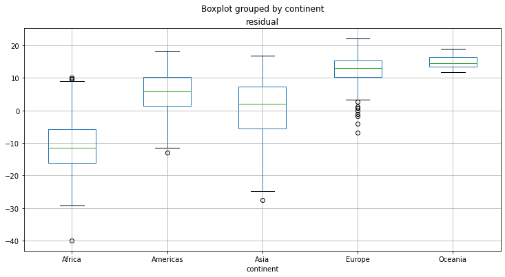

```python
data.boxplot(column='residual', by='continent', figsize=(12,6))
```

### Question 9

Is there a dependence between model residual and continent? If so, what would that suggest when performing a regression analysis of life expectancy across time?

The residual definitely varies depending on continent, with Asia fitting the linear regression the best and Oceana fitting it the least. That suggests that the linear regression should be separated by continent, as it would yield different results.

### Exercise 5

```
Asia life expectancy = 0.4531224038991313 * year + ( -836.8908952860071 )
Europe life expectancy = 0.2219321445221446 * year + ( -367.4109939704742 )
Africa life expectancy = 0.2895292630446477 * year + ( -524.257846068675 )
Americas life expectancy = 0.3676509370629371 * year + ( -663.1062932494174 )
Oceania life expectancy = 0.21027237762237763 * year + ( -341.90796317016316 )
```

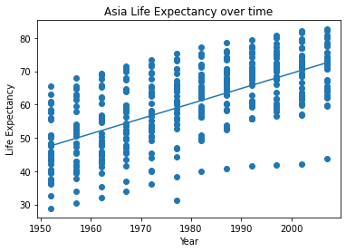

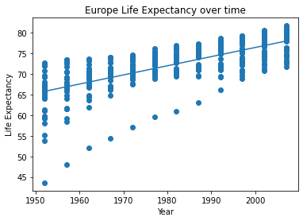

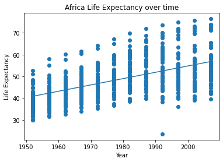

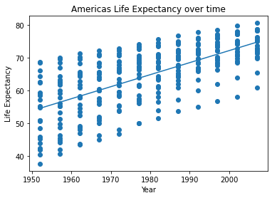

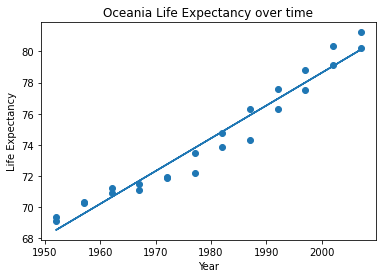

```python
continents = data['continent'].unique()
for c in continents:
    plt.figure()
    x = data.loc[data['continent'] == c]['year']
    y = data.loc[data['continent'] == c]['lifeExp']
    plt.scatter(x,y)
    year = np.array([[i] for i in x])
    reg.fit(year, y)
    print(c, "life expectancy =", reg.coef_[0], "* year + (", reg.intercept_, ")")
    plt.plot(x, reg.coef_[0]*x + reg.intercept_)
    plt.title(c+' Life Expectancy over time')
    plt.xlabel('Year')
    plt.ylabel("Life Expectancy")
```

### Question 10

Based on this plot, should your regression model include an interaction term for continent and year? Why?

Yes, because the intercepts and coefficients vary greatly by continent, so predictions using a general linear regression for all continents will likely be very off.

### Exercise 6

```python
X = []
for c, y in zip(data['continent'], data['year']):
    if c=='Asia':
        X.append([1, 0, 0, 0, 0, y])
    elif c=='Europe':
        X.append([0, 1, 0, 0, 0, y])
    elif c=='Africa':
        X.append([0, 0, 1, 0, 0, y])
    elif c=='Americas':
        X.append([0, 0, 0, 1, 0, y])
    elif c=='Oceania':
        X.append([0, 0, 0, 0, 1, y])


interaction = PolynomialFeatures(degree=6, include_bias=False, interaction_only=True)
X_inter = interaction.fit_transform(X)

regr = linear_model.LinearRegression()

model = regr.fit(X_inter, data['lifeExp'])
list(zip(model.coef_, interaction.get_feature_names(['Asia', 'Europe', 'Africa', 'Americas', 'Oceania', 'year'])))
```

```
[(1694248348.6807609, 'Asia'),
 (1694248815.7856638, 'Europe'),
 (1694248659.114999, 'Africa'),
 (1694248519.9950175, 'Americas'),
 (1694248841.569849, 'Oceania'),
 (-81445274239.36662, 'year'),
 (3015181432.156134, 'Asia Europe'),
 (1506458203.2576578, 'Asia Africa'),
 (705159393.8575807, 'Asia Americas'),
 (-701808625.6357676, 'Asia Oceania'),
 (81445274239.81876, 'Asia year'),
 (0.0, 'Europe Africa'),
 (0.0, 'Europe Americas'),
 (0.0, 'Europe Oceania'),
 (81445274239.58861, 'Europe year'),
 (0.0, 'Africa Americas'),
 (0.0, 'Africa Oceania'),
 (81445274239.65608, 'Africa year'),
 (0.0, 'Americas Oceania'),
 (81445274239.7342, 'Americas year'),
 (81445274239.57686, 'Oceania year'),
 (0.0, 'Asia Europe Africa'),
 (0.0, 'Asia Europe Americas'),
 (0.0, 'Asia Europe Oceania'),
 (0.0, 'Asia Europe year'),
 (0.0, 'Asia Africa Americas'),
 (0.0, 'Asia Africa Oceania'),
 (0.0, 'Asia Africa year'),
 (0.0, 'Asia Americas Oceania'),
 (0.0, 'Asia Americas year'),
 (0.0, 'Asia Oceania year'),
 (0.0, 'Europe Africa Americas'),
 (0.0, 'Europe Africa Oceania'),
 (0.0, 'Europe Africa year'),
 (0.0, 'Europe Americas Oceania'),
 (0.0, 'Europe Americas year'),
 (0.0, 'Europe Oceania year'),
 (0.0, 'Africa Americas Oceania'),
 (0.0, 'Africa Americas year'),
 (0.0, 'Africa Oceania year'),
```

[output cut: 8 more lines]

```
 (0.0, 'Asia Africa Americas year'),
 (0.0, 'Asia Africa Oceania year'),
 (0.0, 'Asia Americas Oceania year'),
 (0.0, 'Europe Africa Americas Oceania'),
 (0.0, 'Europe Africa Americas year'),
 (0.0, 'Europe Africa Oceania year'),
 (0.0, 'Europe Americas Oceania year'),
 (0.0, 'Africa Americas Oceania year'),
 (0.0, 'Asia Europe Africa Americas Oceania'),
 (0.0, 'Asia Europe Africa Americas year'),
 (0.0, 'Asia Europe Africa Oceania year'),
 (0.0, 'Asia Europe Americas Oceania year'),
 (0.0, 'Asia Africa Americas Oceania year'),
 (0.0, 'Europe Africa Americas Oceania year'),
 (0.0, 'Asia Europe Africa Americas Oceania year')]
```

### Question 11

Are all parameters in the model significantly different from zero? If not, which are not significantly different from zero?

Not all are significantly different from zero. The ones that are impossible to exist as an input (for example, being in both Europe and Africa) (almost all) have coefficient of zero. Inputs that are just one continent and a year do get different outputs based on the input, so they have coefficients significantly larger than zero.

### Question 12

On average, by how much does life expectancy increase each year for each continent? (Provide code to answer this question by extracting relevant estimates from model fit)

The relevant coefficients the model gave were

(-81445274239.36662, 'year'),  
(81445274239.81876, 'Asia year'),  
(81445274239.58861, 'Europe year'),  
(81445274239.65608, 'Africa year'),  
(81445274239.7342, 'Americas year'),  
(81445274239.57686, 'Oceania year').

### Exercise 8:

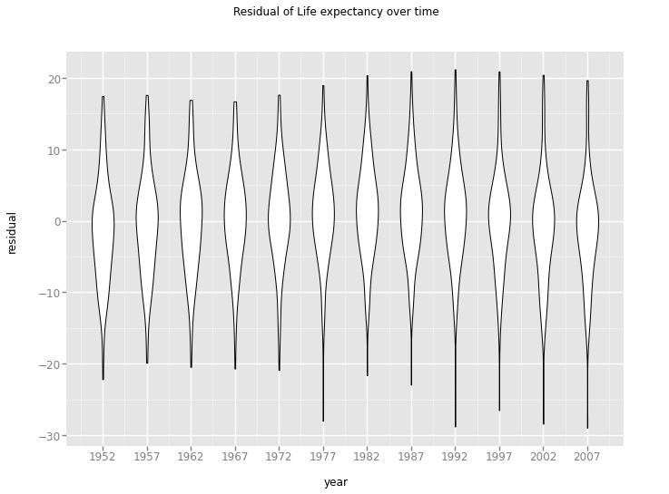

```python
predictionInteraction = []

for i in X:
    predictionInteraction.append(model.coef_[0]*i[0]+
     model.coef_[1]*i[1]+
     model.coef_[2]*i[2]+
     model.coef_[3]*i[3]+
     model.coef_[4]*i[4]+
     model.coef_[5]*i[5]+
     model.coef_[6]*i[0]*i[1]+
     model.coef_[7]*i[0]*i[2]+
     model.coef_[8]*i[0]*i[3]+
     model.coef_[9]*i[0]*i[4]+
     model.coef_[10]*i[0]*i[5]+
     model.coef_[14]*i[1]*i[5]+
     model.coef_[17]*i[2]*i[5]+
     model.coef_[19]*i[3]*i[5]+
     model.coef_[20]*i[4]*i[5]+
     +model.intercept_)


data['residualInteraction'] = data['lifeExp']-predictionInteraction
ggplot(aes(x='year', y='residualInteraction'), data=data) +\
    geom_violin() +\
    labs(title="Residual of Life expectancy over time",
         x = "year",
         y = "residual")
```

Since the violin plot is now unimodal and symmetric around 0 for all years, it means the distribution of residuals is symmetric and normally distributed. That means our new model fits the data very well, as most residues are 0 or close to 0.

## Part 2: Classification

### Problem 1

Stochastic algorithm from class

```python
def grad_descent(X, y, T, alpha):
    m, n = X.shape

    #fill in theta and f with zeros
    theta = np.zeros(n)
    f = np.zeros(T)

    for i in range(T):
        #calculate the loss
        f[i] = np.linalg.norm(X.dot(theta)-y, 1)
        #steepest ascent at f(theta)
        g = X.T.dot(np.sign(X.dot(theta)-y))
        #gradient step
        theta = theta - alpha*g

    return theta, f
```

### Problem 3

Stochastic algorithm from class, modified

```python
def grad_descent_log(X, y, T, alpha):
    m, n = X.shape

    #fill in theta and f with zeros
    theta = np.zeros(n)
    f = np.zeros(T)

    for i in range(T):
        #calculate the loss
        f[i] = np.linalg.norm(X.dot(theta)-y, 1)
        #steepest ascent at f(theta)
        fbk = X.dot(theta)
        pbk = [np.exp(j)/(1+np.exp(j)) for j in fbk]
        g = X.T.dot([j-k for j, k in zip(y,pbk)])
        #gradient step
        theta = theta + alpha*g

    return theta, f
```

### Problem 4

```python
# Generate data for linear regression:
gen_data_x, gen_data_y = datasets.make_regression(n_samples=100, n_features=20, noise = 1.5)
# Scikit Learn linear regression
regr = linear_model.LinearRegression()
model = regr.fit(gen_data_x, gen_data_y)
```

```
slope: 1.0002067885858448 intercept: 0.014610553370333143
```

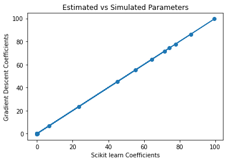

```python
theta, f = grad_descent(gen_data_x, gen_data_y, 100000, 0.0001)

plt.scatter(model.coef_[0:20], theta)
plt.xlabel('Scikit learn Coefficients')
plt.ylabel('Gradient Descent Coefficients')
plt.title('Estimated vs Simulated Parameters')

m, b = np.polyfit(model.coef_[0:20], theta, 1)
plt.plot(model.coef_[0:20], model.coef_[0:20]*m+b)
print('slope:', m, 'intercept:', b)
```

The gradient descent for linear regression works very well, as the ratio between gradient descent coeficients and Scikit's is almost 1, and the intercept is almost 0.

```python
# Generate data for logistic regression. This is similar to linear, only now values are either 0 or 1.
log_gen_data_x, dump_y = datasets.make_regression(n_samples=100, n_features=20, noise = 1.5)
# Scikit Learn logistic regression
regr = linear_model.LogisticRegression()
model = regr.fit(log_gen_data_x, log_gen_data_y)
```

```
slope: 0.24649133795339404 intercept: -0.29837610909545464
```

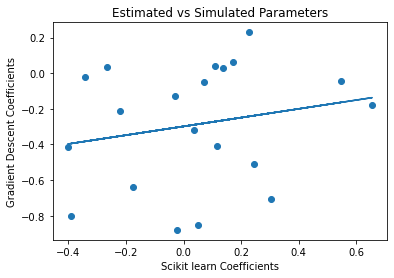

```python
log_gen_data_y = [0 if i>0 else 1 for i in dump_y]

theta, f = grad_descent_log(log_gen_data_x, log_gen_data_y, 1000, 0.0001)

plt.scatter(model.coef_[0][0:20], theta)
plt.xlabel('Scikit learn Coefficients')
plt.ylabel('Gradient Descent Coefficients')
plt.title('Estimated vs Simulated Parameters')

m, b = np.polyfit(model.coef_[0][0:20], theta, 1)
plt.plot(model.coef_[0][0:20], model.coef_[0][0:20]*m+b)
print('slope:', m, 'intercept:', b)
```

The gradient descent for logistic regression does not work well. With the right T and alpha it is possible to get the gradient descent coefficients in the same general range as the scikit learn ones, but from the scatter plot they are clearly not the same coefficients, as the slope and intercept values are not 1 and 0.

### Try it out

The dataset being used is the Iris dataset from scikit learn. The columns are the sepal length, width, petal length, width, and a categorical target of the species of iris.

```python
iris = datasets.load_iris()
df_iris = pd.DataFrame(iris.data, columns=['sepal length', 'sepal width', 'petal length', 'petal width'])
df_iris['target'] = iris.target
df_iris
```

|  | sepal length | sepal width | petal length | petal width | target |
| --- | --- | --- | --- | --- | --- |
| 0 | 5.1 | 3.5 | 1.4 | 0.2 | 0 |
| 1 | 4.9 | 3.0 | 1.4 | 0.2 | 0 |
| 2 | 4.7 | 3.2 | 1.3 | 0.2 | 0 |
| 3 | 4.6 | 3.1 | 1.5 | 0.2 | 0 |
| 4 | 5.0 | 3.6 | 1.4 | 0.2 | 0 |
| ... | ... | ... | ... | ... | ... |
| 145 | 6.7 | 3.0 | 5.2 | 2.3 | 2 |
| 146 | 6.3 | 2.5 | 5.0 | 1.9 | 2 |
| 147 | 6.5 | 3.0 | 5.2 | 2.0 | 2 |
| 148 | 6.2 | 3.4 | 5.4 | 2.3 | 2 |
| 149 | 5.9 | 3.0 | 5.1 | 1.8 | 2 |

150 rows × 5 columns

```python
kf = KFold(n_splits=10)
dtree_splits = []
for train, test in kf.split(df_iris):
    dtree_splits.append((train, test))
```

### Logistic Regression Gradient Descent

```python
log_scores = []
log_prediction = []
for (train, test) in dtree_splits:
    theta, f = grad_descent_log(iris.data[train], iris.target[train], 1000, 0.0000001)
    for x in iris.data[test]:
        log_prediction.append(np.dot(x, theta))
    log_scores.append(r2_score(iris.target[test], log_prediction[-len(test):]))

print("Logistic Regression Gradient Descent R2 scores accuracy", np.mean(log_scores), ", Standard error", np.std(log_scores))
```

```
Logistic Regression Gradient Descent R2 scores accuracy -0.2939896242275372 , Standard error 0.935412343411491
```

The logistic regression gradient descent shows a negative r2, which sklearn's documentation says is possible. Since it is closer to 0 than it is to 1, it means that the model is not very good at predicting.

### Decision Tree

```python
# With KFold and scores method
tree_scores = []
tree_prediction = []
for (train, test) in dtree_splits:
    clf = tree.DecisionTreeClassifier()
    clf = clf.fit(iris.data[train], iris.target[train])
    tree_prediction.extend(clf.predict(iris.data[test]))
    tree_scores.append(clf.score(iris.data[test], iris.target[test]))

print("Decision Tree KFold scores accuracy", np.mean(tree_scores), ", Standard error", np.std(tree_scores))


# Or with cross_val_score function
tree_scores = cross_val_score(clf, iris.data, iris.target, cv=10)
print("Decision Tree cross value accuracy", tree_scores.mean(), ", Standard error", tree_scores.std())
```

```
Decision Tree KFold scores accuracy 0.9333333333333333 , Standard error 0.08432740427115679
Decision Tree cross value accuracy 0.96 , Standard error 0.044221663871405324
```

The Decision Tree accuracy is very high, with KFold scores and CV scores about 90%, and has a low standard error, meaning the scores are all rather close to each other.

### Linear SVC

```python
# With KFold and scores method
svc_scores = []
svc_prediction = []
for (train, test) in dtree_splits:
    clf = make_pipeline(StandardScaler(), LinearSVC(random_state=0, tol=1e-5))
    clf = clf.fit(iris.data[train], iris.target[train])
    svc_prediction.extend(clf.predict(iris.data[test]))
    svc_scores.append(clf.score(iris.data[test], iris.target[test]))

print("Linear SVC KFold scores accuracy", np.mean(svc_scores), ", Standard error", np.std(svc_scores))


# Or with cross_val_score function
svc_scores = cross_val_score(clf, iris.data, iris.target, cv=10)
print("Linear SVC cross value accuracy", svc_scores.mean(), ", Standard error", svc_scores.std())
```

```
Linear SVC KFold scores accuracy 0.9200000000000002 , Standard error 0.08844332774281068
Linear SVC cross value accuracy 0.9400000000000001 , Standard error 0.05537749241945381
```

The Linear SVC accuracy is very high, with KFold scores and CV scores about 90%, and has a low standard error as well. However, it's accuracy is slightly less than the decision tree's.

### t-test

```python
# Log regression and Decision Tree
stats.ttest_rel(log_prediction, tree_prediction)
```

```
Ttest_relResult(statistic=30.525905909738782, pvalue=5.417430852334027e-66)
```

```python
# Log regression and Linear SVC
stats.ttest_rel(log_prediction, svc_prediction)
```

```
Ttest_relResult(statistic=29.89569641443374, pvalue=7.861249565310843e-65)
```

```python
# Decision Tree and Linear SVC
stats.ttest_rel(tree_prediction, svc_prediction)
```

```
Ttest_relResult(statistic=-1.6422035742213938, pvalue=0.10265670235545438)
```

Since my logistic regression gradient descent performs poorly, the t-tests and p-values when comparing to decision tree and linear svc show extreme values. The p-value is very small (<0.05), so they do not predict similarly at all. When doing a t-test between decision tree and linear svc, the results are more reasonable, with a p-value > 0.05, indicating that a null hypothesis of the two making the same prediction should not be rejected.